# Clustering weekend homework

# Loading in Libraries

```r
library(cluster)
library(factoextra)
library(dendextend)
library(broom)
library(animation)
library(janitor)
library(cluster)
library(GGally)
library(tidyverse)
```

# Reading in and Cleaning data

```r
mall_data <- read_csv("mall_customers.csv") %>%
  clean_names() %>%
  rename(spending_score = spending_score_1_100,
         annual_income = annual_income_k)
```

# Initial Exploratory Analysis

```r
summary(mall_data)
```

```
  customer_id        gender               age        annual_income
 Min.   :  1.00   Length:200         Min.   :18.00   Min.   : 15.00
 1st Qu.: 50.75   Class :character   1st Qu.:28.75   1st Qu.: 41.50
 Median :100.50   Mode  :character   Median :36.00   Median : 61.50
 Mean   :100.50                      Mean   :38.85   Mean   : 60.56
 3rd Qu.:150.25                      3rd Qu.:49.00   3rd Qu.: 78.00
 Max.   :200.00                      Max.   :70.00   Max.   :137.00
 spending_score
 Min.   : 1.00
 1st Qu.:34.75
 Median :50.00
 Mean   :50.20
 3rd Qu.:73.00
 Max.   :99.00
```

```r
head(mall_data)
```

| customer_id | gender | age | annual_income | spending_score |
| --- | --- | --- | --- | --- |
| 1 | Male | 19 | 15 | 39 |
| 2 | Male | 21 | 15 | 81 |
| 3 | Female | 20 | 16 | 6 |
| 4 | Female | 23 | 16 | 77 |
| 5 | Female | 31 | 17 | 40 |
| 6 | Female | 22 | 17 | 76 |

```r
mall_data %>%
  group_by(gender) %>%
  summarise(n())
```

| gender | n() |
| --- | --- |
| Female | 112 |
| Male | 88 |

```r
mall_data %>%
  summarise(max(age))
```

| max(age) |
| --- |
| 70 |

```r
mall_data %>%
  summarise(min(age))
```

| min(age) |
| --- |
| 18 |

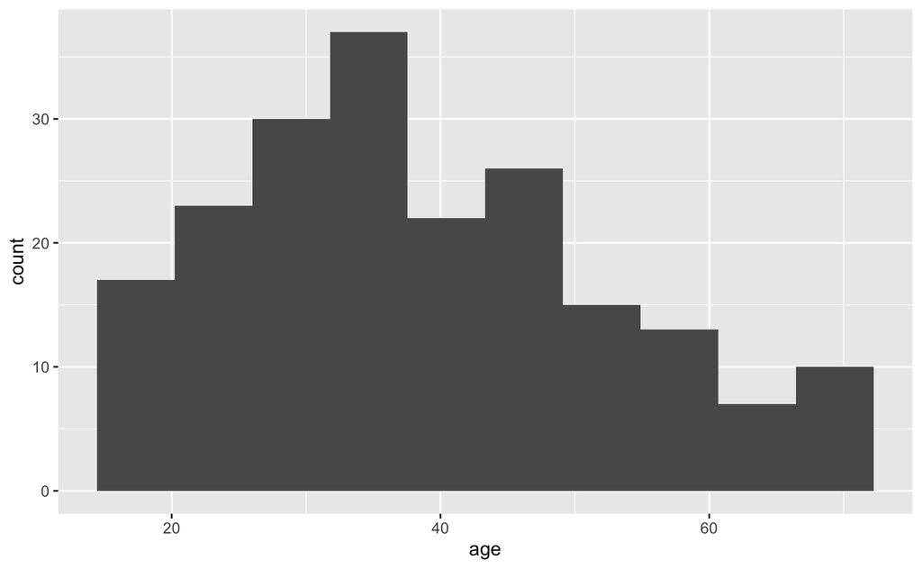

```r
ggplot(mall_data) +
  aes(x = age) +
  geom_histogram(bins = 10)
```

Initial analysis:

Number of cols + 5 Data is pre scaled customer age groups between 18-70 and there seems to be a bimodal distr to these ages.

# Plot data

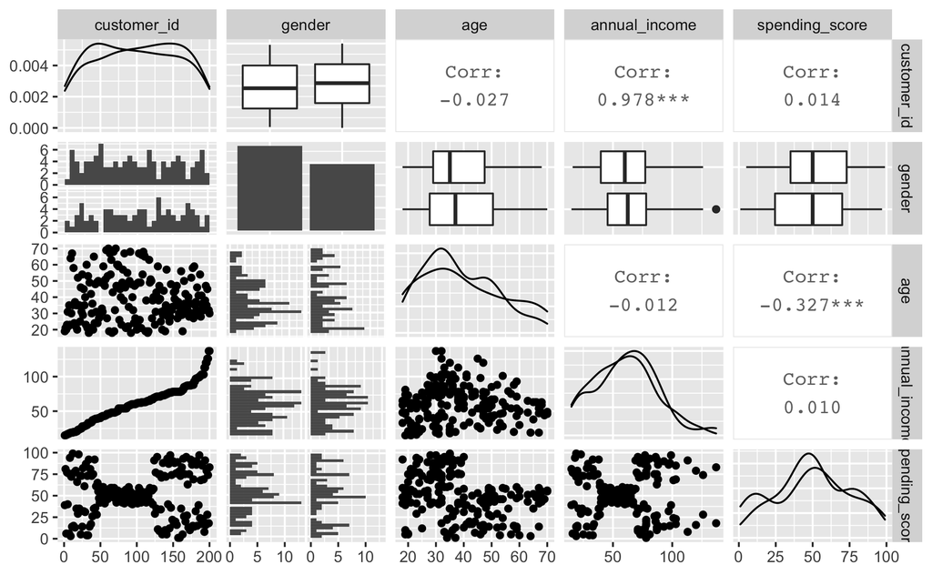

```r
mall_data %>%
ggpairs(mall_data, progress = FALSE)
```

Lets have a look at spending_score & annual_income

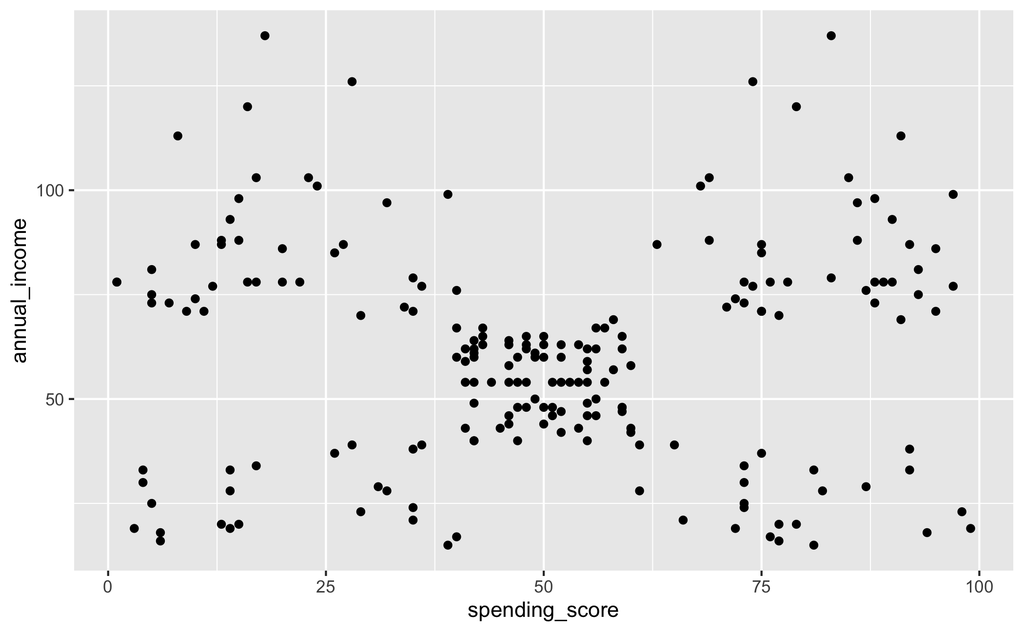

```r
ggplot(mall_data) +
  aes(x = spending_score, y = annual_income) +
  geom_point()
```

There is potential evidence of clustering after plotting spending_score and annual_income.

K-means clustering is an ideal technique to try identfify meaningful clusters in the data to target the customers.

# Selecting only spending_score and annual_income

```r
mall_trimmed <- mall_data %>%
  select(annual_income, spending_score)
```

# Choosing a k_value

3 methods will be used to identitfy the optimal k value - elbow method, silhoulette coefficient and gap statistic.

## Elbow

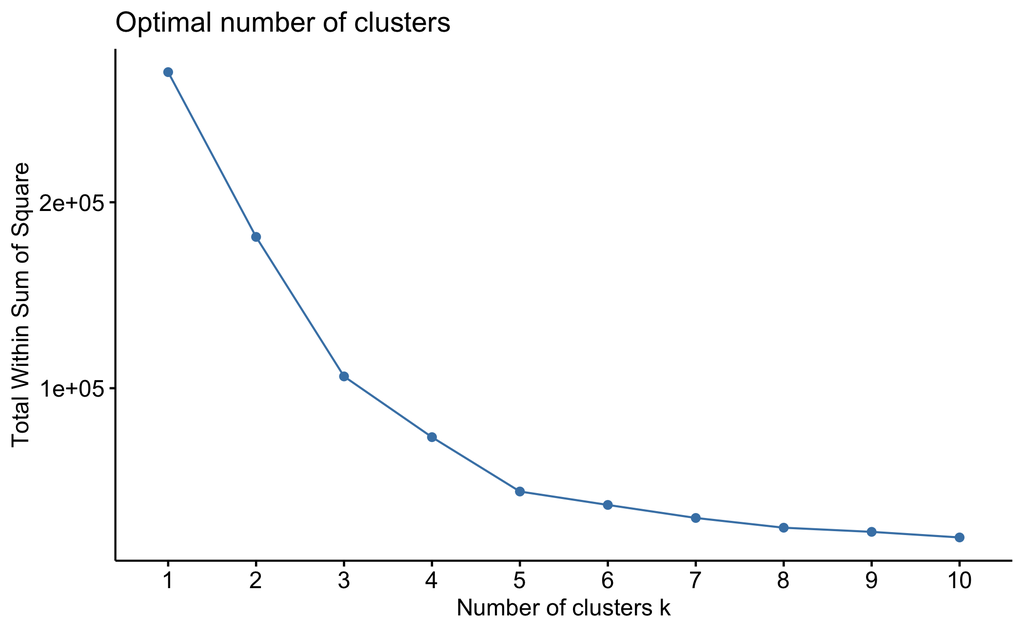

```r
fviz_nbclust(mall_trimmed, kmeans, method = "wss", nstart = 25)
```

The elbow indicates that the optimal k-value could be either 3 or 5.

## Silhouette

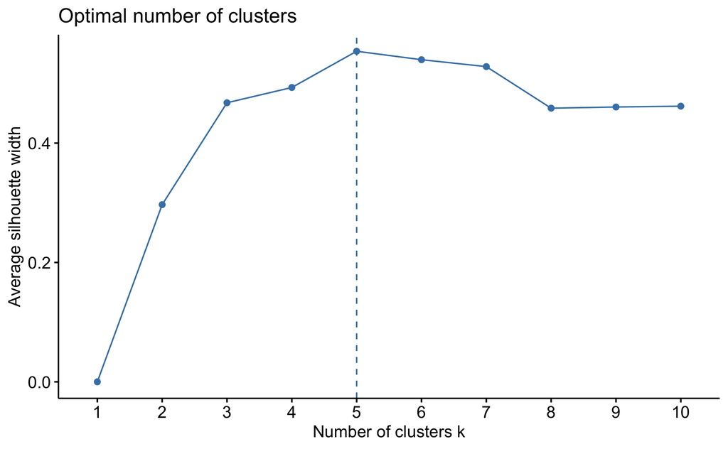

```r
fviz_nbclust(mall_trimmed, kmeans, method = "silhouette", nstart = 25)
```

The Silhouette method indicates that the optimal k-value is 5.

## Gap

```
Clustering k = 1,2,..., K.max (= 10): .. done
Bootstrapping, b = 1,2,..., B (= 100)  [one "." per sample]:
.................................................. 50
.................................................. 100
```

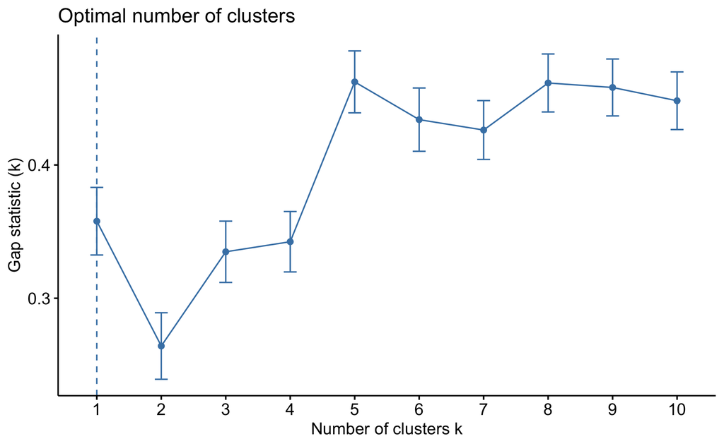

```r
fviz_nbclust(mall_trimmed, kmeans, method = "gap_stat", nstart = 25, k.max = 10)
```

Gap statistic shows that 1 should be the k-value

Based on results from all 3 methods, 5 is the most common number to have been identified as optimal so I will proceed with this number.

# K means clustering

```r
clustered_mall_data <- kmeans(mall_trimmed, 5, nstart = 25)
clustered_mall_data$size
```

```
[1] 35 22 39 23 81
```

```r
clustered_mall_data$centers
```

```
  annual_income spending_score
1      88.20000       17.11429
2      25.72727       79.36364
3      86.53846       82.12821
4      26.30435       20.91304
5      55.29630       49.51852
```

# K means visualisation

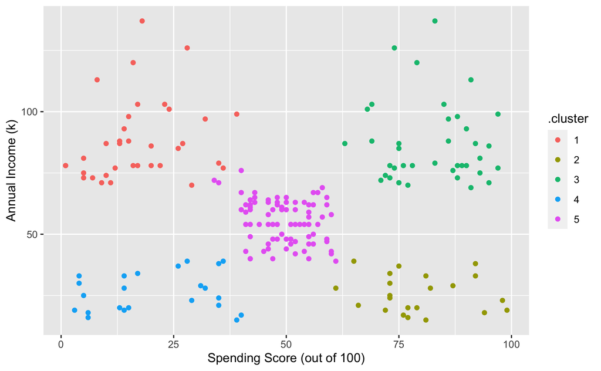

```r
clusters <- augment(clustered_mall_data, mall_data)
ggplot(clusters, aes(x = spending_score, y = annual_income, colour = .cluster)) +
  geom_point() +
  labs(x = "Spending Score (out of 100)", y = "Annual Income (k)")
```

From the visualisation it can be said there is evidence that the among the customer data there are 5 distinct groupings. Generally there appears to be little spread of data points within each cluster and this indicates that the clustering is a good fit.

# Labelling cluster 5

Within all 5 clusters there looks to be a commonality in attributes but this is particularly evident in the central purple cluster, cluster 5.

# Labelling Cluster 5

```r
cluster_5 <- clusters %>%
  filter(.cluster == "5")
```

```r
cluster_5 %>%
  summarise(max_age = max(age),
            min_age = min(age),
            max_income = max(annual_income),
            min_income = min(annual_income)
            )
```

| max_age | min_age | max_income | min_income |
| --- | --- | --- | --- |
| 70 | 18 | 76 | 39 |

```r
cluster_5_gender <- cluster_5 %>%
  group_by(gender) %>%
  summarise(count = n()) %>%
  mutate(gender_percent = round(count/sum(count), digits = 3) * 100)
cluster_5_gender
```

| gender | count | gender_percent |
| --- | --- | --- |
| Female | 48 | 59.3 |
| Male | 33 | 40.7 |

```r
cluster_5_averages <- cluster_5 %>%
  summarise(average_age = round(mean(age), digits = 1),
            average_income = round(mean(annual_income), digits = 2),
            average_spending_score = round(mean(spending_score), digits = 1))
cluster_5_averages
```

| average_age | average_income | average_spending_score |
| --- | --- | --- |
| 42.7 | 55.3 | 49.5 |